# 4 Classifying hand-written digits

In this lesson, we will classify hand-written digits using the persistence homology and some tricks.

## 4.1 Loading packages

```julia
import MLDatasets
using Images, Makie, CairoMakie
using Distances
using Ripserer, PersistenceDiagrams
using StatsBase: mean
import Plots;
using DataFrames, FreqTables, PrettyTables
using Flux, ProgressMeter
```

## 4.2 The dataset

MNIST is a dataset consisting of 70.000 hand-written digits. Each digit is a 28x28 grayscale image, that is: a 28x28 matrix of values from 0 to 1. To get this dataset, run

```julia
n_train = 10_000
mnist_digits, mnist_labels = MLDatasets.MNIST(split=:train)[:];
mnist_digits = mnist_digits[:, :, 1:n_train]
mnist_labels = mnist_labels[1:n_train];
```

If the console asks you to download some data, just press `y`.

Notice that we only get the first `n_train` images so this notebook doesn’t take too much time to run. You can increase `n_train` to 60000 if you like to live dangerously and have enough RAM memory.

Next, we transpose the digits and save them in a vector

```julia
figs = [mnist_digits[:, :, i]' |> Matrix for i ∈ 1:size(mnist_digits)[3]];
```

The first digit, for example, is the following matrix:

```julia
figs[1]
```

```
28×28 Matrix{Float32}:
 0.0  0.0  0.0  0.0  0.0       0.0       …  0.0       0.0  0.0  0.0  0.0
 0.0  0.0  0.0  0.0  0.0       0.0          0.0       0.0  0.0  0.0  0.0
 0.0  0.0  0.0  0.0  0.0       0.0          0.0       0.0  0.0  0.0  0.0
 0.0  0.0  0.0  0.0  0.0       0.0          0.0       0.0  0.0  0.0  0.0
 0.0  0.0  0.0  0.0  0.0       0.0          0.0       0.0  0.0  0.0  0.0
 0.0  0.0  0.0  0.0  0.0       0.0       …  0.498039  0.0  0.0  0.0  0.0
 0.0  0.0  0.0  0.0  0.0       0.0          0.25098   0.0  0.0  0.0  0.0
 0.0  0.0  0.0  0.0  0.0       0.0          0.0       0.0  0.0  0.0  0.0
 0.0  0.0  0.0  0.0  0.0       0.0          0.0       0.0  0.0  0.0  0.0
 0.0  0.0  0.0  0.0  0.0       0.0          0.0       0.0  0.0  0.0  0.0
 0.0  0.0  0.0  0.0  0.0       0.0       …  0.0       0.0  0.0  0.0  0.0
 0.0  0.0  0.0  0.0  0.0       0.0          0.0       0.0  0.0  0.0  0.0
 0.0  0.0  0.0  0.0  0.0       0.0          0.0       0.0  0.0  0.0  0.0
 ⋮                             ⋮         ⋱                 ⋮
 0.0  0.0  0.0  0.0  0.0       0.0          0.0       0.0  0.0  0.0  0.0
 0.0  0.0  0.0  0.0  0.0       0.0          0.0       0.0  0.0  0.0  0.0
 0.0  0.0  0.0  0.0  0.0       0.0          0.0       0.0  0.0  0.0  0.0
 0.0  0.0  0.0  0.0  0.0       0.0          0.0       0.0  0.0  0.0  0.0
 0.0  0.0  0.0  0.0  0.0       0.0       …  0.0       0.0  0.0  0.0  0.0
 0.0  0.0  0.0  0.0  0.0       0.0          0.0       0.0  0.0  0.0  0.0
 0.0  0.0  0.0  0.0  0.0       0.0          0.0       0.0  0.0  0.0  0.0
 0.0  0.0  0.0  0.0  0.215686  0.67451      0.0       0.0  0.0  0.0  0.0
 0.0  0.0  0.0  0.0  0.533333  0.992157     0.0       0.0  0.0  0.0  0.0
 0.0  0.0  0.0  0.0  0.0       0.0       …  0.0       0.0  0.0  0.0  0.0
 0.0  0.0  0.0  0.0  0.0       0.0          0.0       0.0  0.0  0.0  0.0
 0.0  0.0  0.0  0.0  0.0       0.0          0.0       0.0  0.0  0.0  0.0
```

We can see a mosaic with the first 10^2 digits

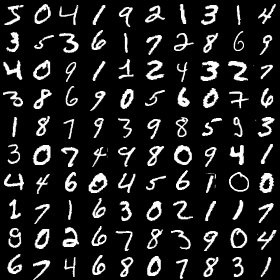

```julia
n = 10
figs_plot = [fig .|> Gray for fig in figs[1:n^2]]
mosaicview(figs_plot, nrow = n, rowmajor = true)
```

## 4.3 A geometrical thinking

What topological tools can be useful to distinguish between different digits?

Persistence homology with Vietoris-Rips filtration won’t be of much help: all digits are connected, so the **0-persistence is useless**; for the 1-dimensional persistence,

- 1, 3, 5, 7 do not contain holes;
- 2 and 4 sometimes contain one hole (depending on the way you write it);
- 0, 6, 9 contain one hole each;
- 8 contains two holes.

What if we starting chopping the digits with sublevels of some functions?

In Chapter 1 we talked about the Vietoris-Rips filtration to obtain a barcode. But there is also another useful way to create barcodes from data: sublevel filtrations.

[figure not shown]

A sublevel filtration uses a real function to slice inverse images and create a sequence of sets, one contained in the another. (Source: Chazal, n.d.).

The *excentricity* function is able to highlight edges. Doing a sublevel filtration with the excentricity function will permit us to separate digits by the amount of edges they have. So 1 and 3 and 7, for example, will have different persistence diagrams.

### 4.3.1 From square matrices to points in the plane

In order to calculate the excentricity, we need to convert the “image digits” (28x28 matrices) to points in $\mathbb{R}^2$ (matrices with 2 columns, one for each dimension, which we will call *pointclouds*). A simple function can do that:

```julia
function img_to_points(img, threshold = 0.3)
    ids = findall(x -> x >= threshold, img)
    pts = getindex.(ids, [1 2])
end;
```

Notice that we had to define a threshold so we only get white pixels.

Let’s also define a function to plot a digit:

```julia
function plot_digit(fig, values = :black)
    pt = img_to_points(fig)
    f = Figure();
    ax = Makie.Axis(f[1, 1], autolimitaspect = 1, yreversed = true)
    scatter!(ax, pt[:, 2], pt[:, 1]; markersize = 40, marker = :rect, color = values)
    if values isa Vector{<:Real}
        Colorbar(f[1, 2])
    end
    f
end;
```

We can see that it works as expected

```julia
fig = figs[3]
heatmap(fig)
```

[figure not shown]

but the image is flipped. This is easily fixed:

```julia
heatmap(fig |> rotr90)
```

[figure not shown]

### 4.3.2 Excentricity

The *excentricity* of a metric space $(X, d)$ is a measure of how far a point is from the “center”. It is defined as follows for each $x \in X$:

$$e(x) = \sum_{y \in X} \frac{d(x, y)}{N}$$

where $N$ is the amount of points of $X$.

Define a function that takes a digit in $\mathbb{R}^2$ and return the excentricity as an 28x28 image

```julia
function excentricity(fig)
    pt = img_to_points(fig)
    dists = pairwise(Euclidean(), pt')
    excentricity = [mean(c) for c ∈ eachcol(dists)]
    exc_matrix = zeros(28, 28)

    for (row, (i, j)) ∈ enumerate(eachrow(pt))
        exc_matrix[i, j] = excentricity[row]
    end

    return exc_matrix
end;
```

We store all the excentricities in the `excs` vector

```julia
excs = excentricity.(figs);
```

and plot a digit with it’s corresponding excentricity

```julia
i = 5
fig = figs[i]
exc = excs[i]
heatmap(exc |> rotr90)
```

[figure not shown]

Looks good! Time to chop it!

### 4.3.3 Persistence images

Now we calculate all the persistence diagrams using sublevel filtration. This can take some seconds. Julia is incredibly fast, but does not perform miracles (yet!).

```julia
pds = map(excs) do ex
    m = maximum(ex)
    ex = m .- ex
    ripserer(Cubical(ex), cutoff = 0.5)
end;
```

We check the first one

```julia
pd = pds[i]
pd |> barcode
```

[figure not shown]

Compare it with the corresponding heatmap above. There are 3 main edges (and one really small one). It seems ok!

We can see the “step-by-step” creation of these connected components in the following mosaic.

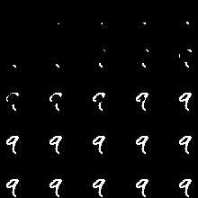

```julia
r = range(minimum(exc), maximum(exc), length = 25) |> reverse
figs_filtration = map(r) do v
    replace(x -> x ≤ v ? 0 : 1, exc) .|> Gray
end

mosaicview(figs_filtration..., rowmajor = true, nrow = 5, npad = 20)
```

Now we create the persistence images of all these barcodes in dimension 0 and 1. We pass the entire collection of barcodes to the `PersistenceImage` function, and it will ensure that all of them are comparable (ie. are on the same grid).

```julia
pds_0 = pds .|> first
pds_1 = pds .|> last
imgs_0 = PersistenceImage(pds_0; sigma = 1, size = 8)
imgs_1 = PersistenceImage(pds_1; sigma = 1, size = 8);
```

The persistence images look ok too:

```julia
Plots.plot(
    barcode(pds[i])
    , Plots.plot(pds[i]; persistence = true)
    , Plots.heatmap(imgs_0(pds[i][1]); aspect_ratio=1)
    ,  Plots.heatmap(imgs_1(pds[i][2]); aspect_ratio=1)
    , layout = (2, 2)
    )
```

[figure not shown]

Top left: the barcode of a digit with respect to sublevels using the excentricity function. Top right: the corresponding persistence diagram. Bottom: 0 and 1 dimensional persistence images. They create a pixelated view of the persistence diagram, using a gaussian blur.

## 4.4 Fitting a model

In order to use these persistence images in a machine learning model, we first need to vectorize them, ie, transform them into a vector. Machine learning models love vectors! The easist way is to just concatenate the persistence images as follows:

```julia
function concatenate_pds(imgs_0, pds_0, imgs_1, pds_1)
    persims = [
        [vec(imgs_0(pds_0[i])); vec(imgs_1(pds_1[i])) ] for i in 1:length(pds)
        ]

    X = reduce(hcat, persims)'
    X
end

X = concatenate_pds(imgs_0, pds_0, imgs_1, pds_1)
y = mnist_labels .|> string;
```

We can see that `X` is a matrix with 10000 rows (the amount of digits) and 128 columns (the persistence images concatenated).

It was also important to convert the `mnist_labels` to strings, because we want to classify the digits (and not do a regression on them).

We now have a vector for each image. What can we do? We need a model that takes a large vector of numbers and try to predict the digit. Neural networks are excellent in finding non-linear relations on vectors. Let’s try one!

Create the layers

```julia
function nn_model(X)
  model = Chain(
      Dense(size(X)[2] => 64)
      ,Dense(64 => 10)
  )
end

model = nn_model(X)
```

```
Chain(
  Dense(128 => 64),                     # 8_256 parameters
  Dense(64 => 10),                      # 650 parameters
)                   # Total: 4 arrays, 8_906 parameters, 35.039 KiB.
```

the loader

```julia
target = Flux.onehotbatch(y, 0:9 .|> string)
loader = Flux.DataLoader((X' .|> Float32, target), batchsize=32, shuffle=true);
```

the optimiser

```julia
optim = Flux.setup(Flux.Adam(0.01), model);
```

and train it

```julia
@showprogress for epoch in 1:100
    Flux.train!(model, loader, optim) do m, x, y
        y_hat = m(x)
        Flux.logitcrossentropy(y_hat, y)
    end
end;
```

The predictions can be made with

```julia
pred_y = model(X' .|> Float32)
pred_y = Flux.onecold(pred_y, 0:9 .|> string);
```

And the accuracy

```julia
accuracy = sum(pred_y .== y) / length(y)
accuracy = round(accuracy * 100, digits = 2)
println("The accuracy on the train set was $accuracy %!")
```

```
The accuracy on the train set was 70.79 %!
```

Not bad, taking into account that we only used the excentricity sublevel filtration.

The confusion matrix is the following:

```julia
tbl = freqtable(y, pred_y)
```

```
10×10 Named Matrix{Int64}
Dim1 ╲ Dim2 │    0     1     2     3     4     5     6     7     8     9
────────────┼───────────────────────────────────────────────────────────
0           │  920     0    21    16     2     6    13     2    13     8
1           │    1  1078     7    11     4     5     0    21     0     0
2           │   19    12   522    83   100    27    19    72   107    30
3           │    6    36    37   757    18    52     7   100    13     6
4           │    0     2    77    13   751     9     2   113     6     7
5           │   13    40    46   310    11   283    14   118     6    22
6           │   19     2    15     5     7     3   664    79     8   212
7           │    2    41    35    49   126    20    42   753     2     0
8           │   13     2    69    10    21     1     4     9   787    28
9           │   13     1    29    17    14     6   219   102    13   564
```

Calculating the proportion of prediction for each digit, we get

```julia
round2(x) = round(100*x, digits = 1)

function prop_table(y1, y2)
    tbl = freqtable(y1, y2)
    tbl_prop = prop(tbl, margins = 1) .|> round2
    tbl_prop
end

tbl_p = prop_table(y, pred_y)
```

```
10×10 Named Matrix{Float64}
Dim1 ╲ Dim2 │    0     1     2     3     4     5     6     7     8     9
────────────┼───────────────────────────────────────────────────────────
0           │ 91.9   0.0   2.1   1.6   0.2   0.6   1.3   0.2   1.3   0.8
1           │  0.1  95.7   0.6   1.0   0.4   0.4   0.0   1.9   0.0   0.0
2           │  1.9   1.2  52.7   8.4  10.1   2.7   1.9   7.3  10.8   3.0
3           │  0.6   3.5   3.6  73.4   1.7   5.0   0.7   9.7   1.3   0.6
4           │  0.0   0.2   7.9   1.3  76.6   0.9   0.2  11.5   0.6   0.7
5           │  1.5   4.6   5.3  35.9   1.3  32.8   1.6  13.7   0.7   2.5
6           │  1.9   0.2   1.5   0.5   0.7   0.3  65.5   7.8   0.8  20.9
7           │  0.2   3.8   3.3   4.6  11.8   1.9   3.9  70.4   0.2   0.0
8           │  1.4   0.2   7.3   1.1   2.2   0.1   0.4   1.0  83.4   3.0
9           │  1.3   0.1   3.0   1.7   1.4   0.6  22.4  10.4   1.3  57.7
```

We see that the biggest errors are the following:

```julia
function top_errors(tbl_p)
    df = DataFrame(
        Digit = Integer[]
        , Prediction = Integer[]
        , Percentage = Float64[]
        )

    for i = eachindex(IndexCartesian(), tbl_p)
        push!(df, (i[1]-1, i[2]-1, tbl_p[i]))
    end

    filter!(row -> row.Digit != row.Prediction, df)
    sort!(df, :Percentage, rev = true)
    df[1:10, :]
end

df_errors = top_errors(tbl_p)
df_errors |> pretty_table
```

```
┌─────────┬────────────┬────────────┐
│   Digit │ Prediction │ Percentage │
│ Integer │    Integer │    Float64 │
├─────────┼────────────┼────────────┤
│       5 │          3 │       35.9 │
│       9 │          6 │       22.4 │
│       6 │          9 │       20.9 │
│       5 │          7 │       13.7 │
│       7 │          4 │       11.8 │
│       4 │          7 │       11.5 │
│       2 │          8 │       10.8 │
│       9 │          7 │       10.4 │
│       2 │          4 │       10.1 │
│       3 │          7 │        9.7 │
└─────────┴────────────┴────────────┘
```

### 4.4.1 The perils of isometric spaces

How to separate “6” and “9”? They are isometric! For some people, “2” and “5” are also isometric (just mirror on the x-axis). Functions that only “see” the metric[^1] (like the excentricity) **will never be able to separate these digits**. In digits, the position of the features is important, so let’s add more slicing filtrations to our arsenal.

To avoid writing all the above code-blocks again, we encapsulate the whole process into a function

```julia
function whole_process(
    mnist_digits, mnist_labels, f
    ; imgs_0 = nothing, imgs_1 = nothing
    , dim_max = 1, sigma = 1, size_persistence_image = 8
    )
    figs = [mnist_digits[:, :, i]' |> Matrix for i ∈ 1:size(mnist_digits)[3]]

    excs = f.(figs);

    pds = map(excs) do ex
        m = maximum(ex)
        ex = m .- ex
        ripserer(Cubical(ex), cutoff = 0.5, dim_max = dim_max)
    end;

    pds_0 = pds .|> first
    pds_1 = pds .|> last

    if isnothing(imgs_0)
        imgs_0 = PersistenceImage(pds_0; sigma = sigma, size = size_persistence_image)
    end
    if isnothing(imgs_1)
        imgs_1 = PersistenceImage(pds_1; sigma = sigma, size = size_persistence_image)
    end

    persims = [
    [vec(imgs_0(pds_0[i])); vec(imgs_1(pds_1[i])) ] for i in eachindex(pds)
    ]

    X = reduce(hcat, persims)'
    y = mnist_labels .|> string

    return X, y, pds_0, pds_1, imgs_0, imgs_1
end;
```

We now create the sideways filtrations: from the side and from above.

```julia
set_value(x, threshold = 0.5, value = 0) = x ≥ threshold ? value : 0

function filtration_sideways(fig; axis = 1, invert = false)

  fig2 = copy(fig)
  if axis == 2 fig2 = fig2' |> Matrix end

  for i ∈ 1:28
    if invert k = 29 - i else k = i end
    fig2[i, :] .= set_value.(fig2[i, :], 0.5, k)
  end

  fig2

end;
```

and calculate all 4 persistence diagrams. Warning: this can take a few seconds if you are using 60000 digits!

```julia
fs = [
    x -> filtration_sideways(x, axis = 1, invert = false)
    ,x -> filtration_sideways(x, axis = 2, invert = false)
    ,x -> filtration_sideways(x, axis = 1, invert = true)
    ,x -> filtration_sideways(x, axis = 2, invert = true)
]

ret = @showprogress map(fs) do f
    whole_process(
        mnist_digits, mnist_labels, f
        ,size_persistence_image = 8
    )
end;
```

We concatenate all the vectors

```julia
X_list = ret .|> first
X_all = hcat(X, X_list...);
```

and try again with a new model:

```julia
model = nn_model(X_all)

target = Flux.onehotbatch(y, 0:9 .|> string)
loader = Flux.DataLoader((X_all' .|> Float32, target), batchsize=64, shuffle=true);

optim = Flux.setup(Flux.Adam(0.01), model)

@showprogress for epoch in 1:50
    Flux.train!(model, loader, optim) do m, x, y
        y_hat = m(x)
        Flux.logitcrossentropy(y_hat, y)
    end
end;
```

Now we have

```julia
pred_y = model(X_all' .|> Float32)
pred_y = Flux.onecold(pred_y, 0:9 .|> string)

accuracy = sum(pred_y .== y) / length(y)
accuracy = round(accuracy * 100, digits = 2)
println("The accuracy on the train set was $accuracy %!")
```

```
The accuracy on the train set was 95.15 %!
```

which is certainly an improvement!

The proportional confusion matrix is

```julia
prop_table(y, pred_y)
```

```
10×10 Named Matrix{Float64}
Dim1 ╲ Dim2 │    0     1     2     3     4     5     6     7     8     9
────────────┼───────────────────────────────────────────────────────────
0           │ 99.6   0.0   0.1   0.0   0.1   0.1   0.1   0.0   0.0   0.0
1           │  0.0  97.6   0.4   0.5   0.1   0.3   0.0   1.2   0.0   0.0
2           │  0.0   1.3  82.2   1.8   0.1   9.3   0.5   4.6   0.0   0.1
3           │  0.0   0.6   0.6  91.3   0.1   2.0   0.0   5.3   0.0   0.1
4           │  0.0   0.2   0.0   0.0  98.4   0.0   0.3   0.5   0.1   0.5
5           │  0.0   1.2   1.5   1.4   0.1  94.2   0.8   0.5   0.0   0.3
6           │  0.0   0.2   0.2   0.0   0.1   0.5  98.9   0.1   0.0   0.0
7           │  0.0   2.2   0.4   0.7   0.1   0.4   0.2  96.0   0.0   0.1
8           │  0.0   0.2   0.7   0.1   1.1   0.3   0.1   0.3  95.0   2.1
9           │  0.0   0.1   0.0   0.0   0.5   0.2   0.2   1.1   0.0  97.9
```

## 4.5 Learning from your mistakes

Let’s explore a bit where the model is making mistakes. Collect all the errors

```julia
errors = findall(pred_y .!= y);
```

and plot the first 3

```julia
i = errors[1]
println("The model predicted a $(pred_y[i]) but it was a $(y[i])")
plot_digit(figs[i])
```

```
The model predicted a 2 but it was a 1
```

[figure not shown]

```julia
i = errors[2]
println("The model predicted a $(pred_y[i]) but it was a $(y[i])")
plot_digit(figs[i])
```

```
The model predicted a 5 but it was a 2
```

[figure not shown]

```julia
i = errors[3]
println("The model predicted a $(pred_y[i]) but it was a $(y[i])")
plot_digit(figs[i])
```

```
The model predicted a 5 but it was a 2
```

[figure not shown]

We can make a mosaic with the first 100 errors

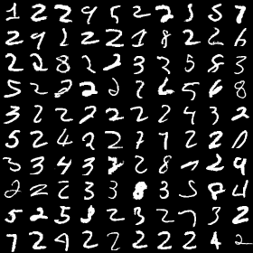

```julia
n = 10
figs_plot = [figs[i] .|> Gray for i in errors[1:n^2]]
mosaicview(figs_plot, nrow = n, rowmajor = true)
```

Many of these digits are really ugly! This makes them hard to classify with our sublevel filtrations. Some other functions could be explored.

## 4.6 Getting new data

Now we want to see if our model really learned something, or if it just repeated what he saw in the training data. To check data, we need to get new data and calculate the accuracy of the same model on this new data.

```julia
n_test = 5_000
new_mnist_digits, new_mnist_labels = MLDatasets.MNIST(split=:test)[:];
new_mnist_digits = new_mnist_digits[:, :, 1:n_test]
new_mnist_labels = new_mnist_labels[1:n_test];
```

and obtaning `X` and `y` to feed the model

```julia
fs = [
    x -> excentricity(x)
    ,x -> filtration_sideways(x, axis = 1, invert = false)
    ,x -> filtration_sideways(x, axis = 2, invert = false)
    ,x -> filtration_sideways(x, axis = 1, invert = true)
    ,x -> filtration_sideways(x, axis = 2, invert = true)
]

ret = @showprogress map(fs) do f
    whole_process(
        new_mnist_digits, new_mnist_labels, f
        ,size_persistence_image = 8
    )
end;
```

Define our new `X` and `y`

```julia
new_X = ret .|> first
new_X = hcat(new_X...)
new_y = ret[1][2]

new_pred_y = model(new_X' .|> Float32)
new_pred_y = Flux.onecold(new_pred_y, 0:9 .|> string);
```

and calculate the accuracy:

```julia
accuracy = sum(new_pred_y .== new_y) / length(new_y)
accuracy = round(accuracy * 100, digits = 2)
println("The accuracy on the test data was $accuracy %!")
```

```
The accuracy on the test data was 86.82 %!
```

A bit less than the training set, but not so bad.

Let’s check the confusion matrix

```julia
tbl = prop_table(new_y, new_pred_y)
```

```
10×10 Named Matrix{Float64}
Dim1 ╲ Dim2 │    0     1     2     3     4     5     6     7     8     9
────────────┼───────────────────────────────────────────────────────────
0           │ 95.4   0.0   0.9   0.2   0.7   0.2   0.7   0.7   0.4   0.9
1           │  0.2  96.3   0.9   0.4   0.4   0.4   0.2   1.4   0.0   0.0
2           │  0.9   0.8  74.0   3.8   1.1  13.2   1.5   3.6   0.9   0.2
3           │  0.2   1.2   4.6  79.0   0.0   5.4   0.2   8.8   0.4   0.2
4           │  0.0   1.0   1.0   0.2  93.8   0.8   0.2   0.8   0.4   1.8
5           │  0.4   1.5   9.4   4.4   1.5  79.2   0.4   1.5   1.1   0.4
6           │  1.5   0.6   2.6   0.2   1.3   2.8  87.4   0.0   3.2   0.2
7           │  0.2   3.3   2.1   2.1   4.9   1.4   0.0  85.4   0.0   0.6
8           │  1.2   0.2   5.1   0.2   0.4   0.6   0.0   0.0  88.5   3.7
9           │  0.2   0.8   0.6   0.0   4.0   0.6   0.4   2.9   1.9  88.7
```

## 4.7 Moral of the story

Even though we used heavy machinery from topology, at the end our persistence images were vectors that indicated the birth and death of connected components and holes. Apart from that, the only machine learning algorithm we used was a [simple dense neural network](https://en.wikipedia.org/wiki/Artificial_neural_network) to fit these vectors to the correct labels in a non-linear way.

State-of-art machine learning models on the MNIST dataset usually can [get more than 99% of accuracy](https://paperswithcode.com/sota/image-classification-on-mnist), but they use some [complicated neural networks](https://en.wikipedia.org/wiki/Convolutional_neural_network) with many layers, and the output prediction are [hard to explain](https://en.wikipedia.org/wiki/Black_box). These methods, however, are not excludent of each other: we can use the persistence images (and any other vectorized output from TDA) together with other algorithms.

### 4.7.1 Exercise left to the reader

A curious reader can try to add more features to the input of the neural network, for example the amount of points, the mean excentricity, the and so on. Addin more features can improve the accuracy of the neural network.

If you are brave enough and want to get in the world of deep learning, a good exercise is to create a neural network with two parallel inputs - one for the digits images, followed by convolutional layers - other for the vector of persistence images, followed by dense layers can achieve a better result than the convolutional alone.

Chazal, Frédéric. n.d. “A Brief Introduction to Persistent Homology.” *Https://Gdr-Gdm.univ-Lr.fr/Ihp-Maths-Meca/Materials/Chazal_ihp_Nov2021.pdf*.

[^1]: ie. are invariant under isometries